# Explanatory analysis

## by Xuejiao Tang

## Investigation Overview

> Discovery the main features which affect the observations.

## Dataset Overview

> The dataset is Ford GoBike System Data downloaded from udacity dataset options. This data set includes information about individual rides made in a bike-sharing system covering the greater San Francisco Bay area.

## (Visualization 1)

> When are most trips taken in terms of time of day?
- Answer: The most trips are taken in the morning, in the afternoon and night there are also a lot of trips. There is few trips in the midnight.

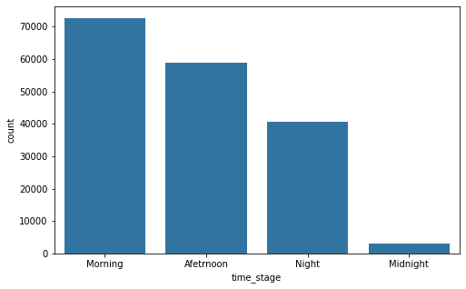

## (Visualization 2)

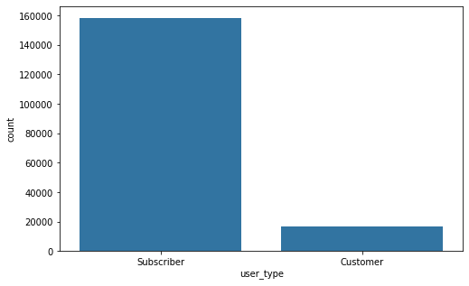

## (Visualization 3)

Do most of the trips last more than one hours?

-Answer: No. Most of the trips last under one hour.

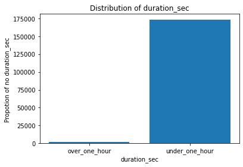

## (Visualization 4)

> The relationship among time_stage, duration_sec, user_type

> Answer: The duration of the subscriber less than the customer. But the time_stage "morgning","afternoon","night", "midnight" do not affect the result.

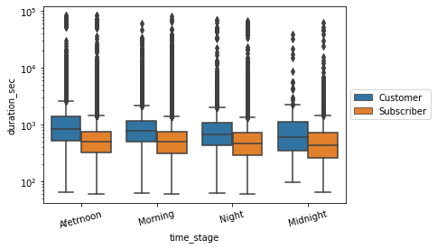

## (Visualization 5)

The relationship among time_stage, duration_sec, user_type and member_birth_year

Answer: The duration of the subscriber less than the customer.The most of users were born in about 1988. But the time_stage "morgning","afternoon","night", "midnight" do not affect the result.

[output not shown]

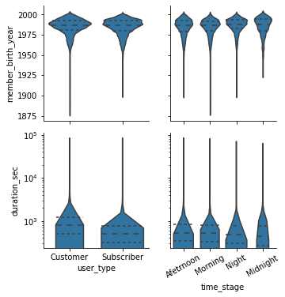

[output not shown]